# Risk Factor Analysis

## Outcome Variable

**Outcome Variable:** wasted

## Predictor Variables

**Intervention Variable:** hfoodsec

**Adjustment Set:**

- arm
- sex
- W_mage
- meducyrs
- feducyrs
- hhwealth_quart
- vagbrth
- W_nrooms
- W_nchldlt5
- brthmon
- W_parity
- impfloor
- impsan
- safeh20
- delta_W_mage
- delta_meducyrs
- delta_feducyrs
- delta_hhwealth_quart
- delta_vagbrth
- delta_W_nrooms
- delta_W_nchldlt5
- delta_brthmon
- delta_W_parity
- delta_impfloor
- delta_impsan
- delta_safeh20

## Stratifying Variables

The analysis was stratified on these variable(s):

- agecat
- studyid
- country

## Data Summary

| agecat | studyid | country | hfoodsec | wasted | n_cell | n |
| --- | --- | --- | --- | --- | --- | --- |
| Birth | ki0047075b-MAL-ED | BANGLADESH | Food Secure | 0 | 125 | 178 |
| Birth | ki0047075b-MAL-ED | BANGLADESH | Food Secure | 1 | 26 | 178 |
| Birth | ki0047075b-MAL-ED | BANGLADESH | Mildly Food Insecure | 0 | 3 | 178 |
| Birth | ki0047075b-MAL-ED | BANGLADESH | Mildly Food Insecure | 1 | 0 | 178 |
| Birth | ki0047075b-MAL-ED | BANGLADESH | Food Insecure | 0 | 19 | 178 |
| Birth | ki0047075b-MAL-ED | BANGLADESH | Food Insecure | 1 | 5 | 178 |
| Birth | ki0047075b-MAL-ED | BRAZIL | Food Secure | 0 | 0 | 102 |
| Birth | ki0047075b-MAL-ED | BRAZIL | Food Secure | 1 | 0 | 102 |
| Birth | ki0047075b-MAL-ED | BRAZIL | Mildly Food Insecure | 0 | 11 | 102 |
| Birth | ki0047075b-MAL-ED | BRAZIL | Mildly Food Insecure | 1 | 0 | 102 |
| Birth | ki0047075b-MAL-ED | BRAZIL | Food Insecure | 0 | 87 | 102 |
| Birth | ki0047075b-MAL-ED | BRAZIL | Food Insecure | 1 | 4 | 102 |
| Birth | ki0047075b-MAL-ED | INDIA | Food Secure | 0 | 128 | 167 |
| Birth | ki0047075b-MAL-ED | INDIA | Food Secure | 1 | 23 | 167 |
| Birth | ki0047075b-MAL-ED | INDIA | Mildly Food Insecure | 0 | 1 | 167 |
| Birth | ki0047075b-MAL-ED | INDIA | Mildly Food Insecure | 1 | 1 | 167 |
| Birth | ki0047075b-MAL-ED | INDIA | Food Insecure | 0 | 10 | 167 |
| Birth | ki0047075b-MAL-ED | INDIA | Food Insecure | 1 | 4 | 167 |
| Birth | ki0047075b-MAL-ED | NEPAL | Food Secure | 0 | 63 | 96 |
| Birth | ki0047075b-MAL-ED | NEPAL | Food Secure | 1 | 12 | 96 |
| Birth | ki0047075b-MAL-ED | NEPAL | Mildly Food Insecure | 0 | 8 | 96 |
| Birth | ki0047075b-MAL-ED | NEPAL | Mildly Food Insecure | 1 | 1 | 96 |
| Birth | ki0047075b-MAL-ED | NEPAL | Food Insecure | 0 | 11 | 96 |
| Birth | ki0047075b-MAL-ED | NEPAL | Food Insecure | 1 | 1 | 96 |
| Birth | ki0047075b-MAL-ED | PERU | Food Secure | 0 | 25 | 105 |
| Birth | ki0047075b-MAL-ED | PERU | Food Secure | 1 | 1 | 105 |
| Birth | ki0047075b-MAL-ED | PERU | Mildly Food Insecure | 0 | 24 | 105 |
| Birth | ki0047075b-MAL-ED | PERU | Mildly Food Insecure | 1 | 0 | 105 |
| Birth | ki0047075b-MAL-ED | PERU | Food Insecure | 0 | 53 | 105 |
| Birth | ki0047075b-MAL-ED | PERU | Food Insecure | 1 | 2 | 105 |

[output cut: 162 more lines]

The following strata were considered:

- agecat: 24 months, studyid: ki0047075b-MAL-ED, country: BANGLADESH
- agecat: 24 months, studyid: ki0047075b-MAL-ED, country: BRAZIL
- agecat: 24 months, studyid: ki0047075b-MAL-ED, country: INDIA
- agecat: 24 months, studyid: ki0047075b-MAL-ED, country: NEPAL
- agecat: 24 months, studyid: ki0047075b-MAL-ED, country: PERU
- agecat: 24 months, studyid: ki0047075b-MAL-ED, country: SOUTH AFRICA
- agecat: 24 months, studyid: ki1017093-NIH-Birth, country: BANGLADESH
- agecat: 24 months, studyid: ki1017093c-NIH-Crypto, country: BANGLADESH
- agecat: 24 months, studyid: ki1113344-GMS-Nepal, country: NEPAL
- agecat: 24 months, studyid: kiGH5241-JiVitA-3, country: BANGLADESH
- agecat: 24 months, studyid: kiGH5241-JiVitA-4, country: BANGLADESH
- agecat: 6 months, studyid: ki0047075b-MAL-ED, country: BANGLADESH
- agecat: 6 months, studyid: ki0047075b-MAL-ED, country: BRAZIL
- agecat: 6 months, studyid: ki0047075b-MAL-ED, country: INDIA
- agecat: 6 months, studyid: ki0047075b-MAL-ED, country: NEPAL
- agecat: 6 months, studyid: ki0047075b-MAL-ED, country: PERU
- agecat: 6 months, studyid: ki0047075b-MAL-ED, country: SOUTH AFRICA
- agecat: 6 months, studyid: ki1017093-NIH-Birth, country: BANGLADESH
- agecat: 6 months, studyid: ki1017093c-NIH-Crypto, country: BANGLADESH
- agecat: 6 months, studyid: ki1113344-GMS-Nepal, country: NEPAL
- agecat: 6 months, studyid: kiGH5241-JiVitA-3, country: BANGLADESH
- agecat: 6 months, studyid: kiGH5241-JiVitA-4, country: BANGLADESH
- agecat: Birth, studyid: ki0047075b-MAL-ED, country: BANGLADESH
- agecat: Birth, studyid: ki0047075b-MAL-ED, country: BRAZIL
- agecat: Birth, studyid: ki0047075b-MAL-ED, country: INDIA
- agecat: Birth, studyid: ki0047075b-MAL-ED, country: NEPAL
- agecat: Birth, studyid: ki0047075b-MAL-ED, country: PERU
- agecat: Birth, studyid: ki0047075b-MAL-ED, country: SOUTH AFRICA
- agecat: Birth, studyid: ki1017093-NIH-Birth, country: BANGLADESH
- agecat: Birth, studyid: ki1017093c-NIH-Crypto, country: BANGLADESH
- agecat: Birth, studyid: kiGH5241-JiVitA-3, country: BANGLADESH
- agecat: Birth, studyid: kiGH5241-JiVitA-4, country: BANGLADESH

### Dropped Strata

Some strata were dropped due to rare outcomes:

- agecat: Birth, studyid: ki0047075b-MAL-ED, country: BANGLADESH
- agecat: Birth, studyid: ki0047075b-MAL-ED, country: BRAZIL
- agecat: Birth, studyid: ki0047075b-MAL-ED, country: INDIA
- agecat: Birth, studyid: ki0047075b-MAL-ED, country: NEPAL
- agecat: Birth, studyid: ki0047075b-MAL-ED, country: PERU
- agecat: Birth, studyid: ki0047075b-MAL-ED, country: SOUTH AFRICA
- agecat: Birth, studyid: ki1017093-NIH-Birth, country: BANGLADESH
- agecat: Birth, studyid: ki1017093c-NIH-Crypto, country: BANGLADESH
- agecat: 6 months, studyid: ki0047075b-MAL-ED, country: BANGLADESH
- agecat: 6 months, studyid: ki0047075b-MAL-ED, country: BRAZIL
- agecat: 6 months, studyid: ki0047075b-MAL-ED, country: INDIA
- agecat: 6 months, studyid: ki0047075b-MAL-ED, country: NEPAL
- agecat: 6 months, studyid: ki0047075b-MAL-ED, country: PERU
- agecat: 6 months, studyid: ki0047075b-MAL-ED, country: SOUTH AFRICA
- agecat: 6 months, studyid: ki1017093-NIH-Birth, country: BANGLADESH
- agecat: 6 months, studyid: ki1017093c-NIH-Crypto, country: BANGLADESH
- agecat: 6 months, studyid: ki1113344-GMS-Nepal, country: NEPAL
- agecat: 24 months, studyid: ki0047075b-MAL-ED, country: BANGLADESH
- agecat: 24 months, studyid: ki0047075b-MAL-ED, country: BRAZIL
- agecat: 24 months, studyid: ki0047075b-MAL-ED, country: INDIA
- agecat: 24 months, studyid: ki0047075b-MAL-ED, country: NEPAL
- agecat: 24 months, studyid: ki0047075b-MAL-ED, country: PERU
- agecat: 24 months, studyid: ki0047075b-MAL-ED, country: SOUTH AFRICA
- agecat: 24 months, studyid: ki1017093-NIH-Birth, country: BANGLADESH

## Methods Detail

We’re interested in the causal parameters $E[Y_a]$ for all values of $a \in \mathcal{A}$. These parameters represent the mean outcome if, possibly contrary to fact, we intervened to set all units to have $A=a$. Under the randomization and positivity assumptions, these are identified by the statistical parameters $\psi_a=E_W[E_{Y|A,W}(Y|A=a,W)]$. In addition, we’re interested in the mean of $Y$, $E[Y]$ under no intervention (the observed mean). We will estimate these parameters by using SuperLearner to fit the relevant likelihood factors – $E_{Y|A,W}(Y|A=a,W)$ and $p(A=a|W)$, and then updating our likelihood fit using a joint TMLE.

For unadjusted analyses ($W=\{\}$), initial likelihoods were estimated using Lrnr_glm to estimate the simple $E(Y|A)$ and Lrnr_mean to estimate $p(A)$. For adjusted analyses, a small library containing Lrnr_glmnet, Lrnr_xgboost, and Lrnr_mean was used.

Having estimated these parameters, we will then use the delta method to estimate relative risks and attributable risks relative to a prespecified baseline level of $A$.

# Results Detail

## Results Plots

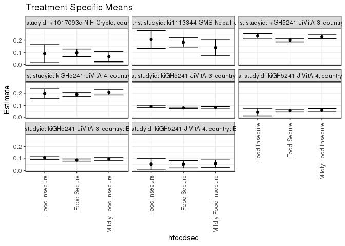

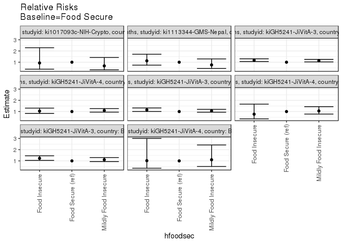

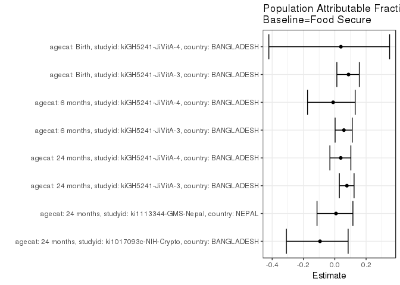

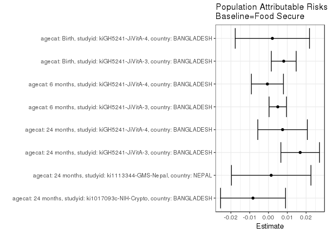

## Results Table

### Parameter: TSM

| agecat | studyid | country | intervention_level | baseline_level | estimate | ci_lower | ci_upper |
| --- | --- | --- | --- | --- | --- | --- | --- |
| Birth | kiGH5241-JiVitA-3 | BANGLADESH | Food Secure | NA | 0.0842365 | 0.0754010 | 0.0930719 |
| Birth | kiGH5241-JiVitA-3 | BANGLADESH | Mildly Food Insecure | NA | 0.0930235 | 0.0819808 | 0.1040663 |
| Birth | kiGH5241-JiVitA-3 | BANGLADESH | Food Insecure | NA | 0.1037331 | 0.0902100 | 0.1172561 |
| Birth | kiGH5241-JiVitA-4 | BANGLADESH | Food Secure | NA | 0.0508761 | 0.0212630 | 0.0804892 |
| Birth | kiGH5241-JiVitA-4 | BANGLADESH | Mildly Food Insecure | NA | 0.0559219 | 0.0264483 | 0.0853954 |
| Birth | kiGH5241-JiVitA-4 | BANGLADESH | Food Insecure | NA | 0.0518006 | 0.0049202 | 0.0986810 |
| 6 months | kiGH5241-JiVitA-3 | BANGLADESH | Food Secure | NA | 0.0797936 | 0.0731297 | 0.0864576 |
| 6 months | kiGH5241-JiVitA-3 | BANGLADESH | Mildly Food Insecure | NA | 0.0847874 | 0.0773199 | 0.0922550 |
| 6 months | kiGH5241-JiVitA-3 | BANGLADESH | Food Insecure | NA | 0.0917792 | 0.0815121 | 0.1020462 |
| 6 months | kiGH5241-JiVitA-4 | BANGLADESH | Food Secure | NA | 0.0568598 | 0.0452161 | 0.0685034 |
| 6 months | kiGH5241-JiVitA-4 | BANGLADESH | Mildly Food Insecure | NA | 0.0599150 | 0.0459992 | 0.0738308 |
| 6 months | kiGH5241-JiVitA-4 | BANGLADESH | Food Insecure | NA | 0.0434030 | 0.0104843 | 0.0763217 |
| 24 months | ki1017093c-NIH-Crypto | BANGLADESH | Food Secure | NA | 0.0958084 | 0.0642126 | 0.1274042 |
| 24 months | ki1017093c-NIH-Crypto | BANGLADESH | Mildly Food Insecure | NA | 0.0645161 | 0.0212336 | 0.1077986 |
| 24 months | ki1017093c-NIH-Crypto | BANGLADESH | Food Insecure | NA | 0.0892857 | 0.0145275 | 0.1640439 |
| 24 months | ki1113344-GMS-Nepal | NEPAL | Food Secure | NA | 0.1833759 | 0.1437845 | 0.2229674 |
| 24 months | ki1113344-GMS-Nepal | NEPAL | Mildly Food Insecure | NA | 0.1391193 | 0.0711033 | 0.2071354 |
| 24 months | ki1113344-GMS-Nepal | NEPAL | Food Insecure | NA | 0.2062386 | 0.1316156 | 0.2808616 |
| 24 months | kiGH5241-JiVitA-3 | BANGLADESH | Food Secure | NA | 0.2010935 | 0.1873319 | 0.2148551 |
| 24 months | kiGH5241-JiVitA-3 | BANGLADESH | Mildly Food Insecure | NA | 0.2283620 | 0.2119832 | 0.2447409 |
| 24 months | kiGH5241-JiVitA-3 | BANGLADESH | Food Insecure | NA | 0.2361809 | 0.2159725 | 0.2563893 |
| 24 months | kiGH5241-JiVitA-4 | BANGLADESH | Food Secure | NA | 0.1892161 | 0.1705691 | 0.2078632 |
| 24 months | kiGH5241-JiVitA-4 | BANGLADESH | Mildly Food Insecure | NA | 0.2074413 | 0.1851216 | 0.2297610 |
| 24 months | kiGH5241-JiVitA-4 | BANGLADESH | Food Insecure | NA | 0.1971406 | 0.1567841 | 0.2374971 |

### Parameter: E(Y)

| agecat | studyid | country | intervention_level | baseline_level | estimate | ci_lower | ci_upper |
| --- | --- | --- | --- | --- | --- | --- | --- |
| Birth | kiGH5241-JiVitA-3 | BANGLADESH | NA | NA | 0.0923316 | 0.0861106 | 0.0985527 |
| Birth | kiGH5241-JiVitA-4 | BANGLADESH | NA | NA | 0.0529412 | 0.0337951 | 0.0720872 |
| 6 months | kiGH5241-JiVitA-3 | BANGLADESH | NA | NA | 0.0847296 | 0.0799320 | 0.0895271 |
| 6 months | kiGH5241-JiVitA-4 | BANGLADESH | NA | NA | 0.0562660 | 0.0473007 | 0.0652313 |
| 24 months | ki1017093c-NIH-Crypto | BANGLADESH | NA | NA | 0.0875486 | 0.0630907 | 0.1120065 |
| 24 months | ki1113344-GMS-Nepal | NEPAL | NA | NA | 0.1848049 | 0.1502971 | 0.2193127 |
| 24 months | kiGH5241-JiVitA-3 | BANGLADESH | NA | NA | 0.2179495 | 0.2080242 | 0.2278748 |
| 24 months | kiGH5241-JiVitA-4 | BANGLADESH | NA | NA | 0.1967070 | 0.1831292 | 0.2102848 |

### Parameter: RR

| agecat | studyid | country | intervention_level | baseline_level | estimate | ci_lower | ci_upper |
| --- | --- | --- | --- | --- | --- | --- | --- |
| Birth | kiGH5241-JiVitA-3 | BANGLADESH | Food Secure | Food Secure | 1.0000000 | 1.0000000 | 1.000000 |
| Birth | kiGH5241-JiVitA-3 | BANGLADESH | Mildly Food Insecure | Food Secure | 1.1043144 | 0.9408646 | 1.296159 |
| Birth | kiGH5241-JiVitA-3 | BANGLADESH | Food Insecure | Food Secure | 1.2314509 | 1.0439424 | 1.452639 |
| Birth | kiGH5241-JiVitA-4 | BANGLADESH | Food Secure | Food Secure | 1.0000000 | 1.0000000 | 1.000000 |
| Birth | kiGH5241-JiVitA-4 | BANGLADESH | Mildly Food Insecure | Food Secure | 1.0991774 | 0.4998486 | 2.417114 |
| Birth | kiGH5241-JiVitA-4 | BANGLADESH | Food Insecure | Food Secure | 1.0181718 | 0.3454041 | 3.001336 |
| 6 months | kiGH5241-JiVitA-3 | BANGLADESH | Food Secure | Food Secure | 1.0000000 | 1.0000000 | 1.000000 |
| 6 months | kiGH5241-JiVitA-3 | BANGLADESH | Mildly Food Insecure | Food Secure | 1.0625842 | 0.9429207 | 1.197434 |
| 6 months | kiGH5241-JiVitA-3 | BANGLADESH | Food Insecure | Food Secure | 1.1502070 | 1.0029302 | 1.319111 |
| 6 months | kiGH5241-JiVitA-4 | BANGLADESH | Food Secure | Food Secure | 1.0000000 | 1.0000000 | 1.000000 |
| 6 months | kiGH5241-JiVitA-4 | BANGLADESH | Mildly Food Insecure | Food Secure | 1.0537321 | 0.7743892 | 1.433841 |
| 6 months | kiGH5241-JiVitA-4 | BANGLADESH | Food Insecure | Food Secure | 0.7633337 | 0.3506154 | 1.661873 |
| 24 months | ki1017093c-NIH-Crypto | BANGLADESH | Food Secure | Food Secure | 1.0000000 | 1.0000000 | 1.000000 |
| 24 months | ki1017093c-NIH-Crypto | BANGLADESH | Mildly Food Insecure | Food Secure | 0.6733871 | 0.3188651 | 1.422075 |
| 24 months | ki1017093c-NIH-Crypto | BANGLADESH | Food Insecure | Food Secure | 0.9319196 | 0.3789294 | 2.291916 |
| 24 months | ki1113344-GMS-Nepal | NEPAL | Food Secure | Food Secure | 1.0000000 | 1.0000000 | 1.000000 |
| 24 months | ki1113344-GMS-Nepal | NEPAL | Mildly Food Insecure | Food Secure | 0.7586565 | 0.4444776 | 1.294912 |
| 24 months | ki1113344-GMS-Nepal | NEPAL | Food Insecure | Food Secure | 1.1246765 | 0.7379344 | 1.714105 |
| 24 months | kiGH5241-JiVitA-3 | BANGLADESH | Food Secure | Food Secure | 1.0000000 | 1.0000000 | 1.000000 |
| 24 months | kiGH5241-JiVitA-3 | BANGLADESH | Mildly Food Insecure | Food Secure | 1.1356013 | 1.0289564 | 1.253299 |
| 24 months | kiGH5241-JiVitA-3 | BANGLADESH | Food Insecure | Food Secure | 1.1744832 | 1.0567077 | 1.305386 |
| 24 months | kiGH5241-JiVitA-4 | BANGLADESH | Food Secure | Food Secure | 1.0000000 | 1.0000000 | 1.000000 |
| 24 months | kiGH5241-JiVitA-4 | BANGLADESH | Mildly Food Insecure | Food Secure | 1.0963195 | 0.9487132 | 1.266891 |
| 24 months | kiGH5241-JiVitA-4 | BANGLADESH | Food Insecure | Food Secure | 1.0418808 | 0.8298346 | 1.308111 |

### Parameter: PAR

| agecat | studyid | country | intervention_level | baseline_level | estimate | ci_lower | ci_upper |
| --- | --- | --- | --- | --- | --- | --- | --- |
| Birth | kiGH5241-JiVitA-3 | BANGLADESH | Food Secure | NA | 0.0080951 | 0.0014823 | 0.0147079 |
| Birth | kiGH5241-JiVitA-4 | BANGLADESH | Food Secure | NA | 0.0020651 | -0.0177079 | 0.0218381 |
| 6 months | kiGH5241-JiVitA-3 | BANGLADESH | Food Secure | NA | 0.0049359 | 0.0003188 | 0.0095531 |
| 6 months | kiGH5241-JiVitA-4 | BANGLADESH | Food Secure | NA | -0.0005938 | -0.0091115 | 0.0079239 |
| 24 months | ki1017093c-NIH-Crypto | BANGLADESH | Food Secure | NA | -0.0082597 | -0.0255539 | 0.0090344 |
| 24 months | ki1113344-GMS-Nepal | NEPAL | Food Secure | NA | 0.0014290 | -0.0197223 | 0.0225803 |
| 24 months | kiGH5241-JiVitA-3 | BANGLADESH | Food Secure | NA | 0.0168560 | 0.0065897 | 0.0271223 |
| 24 months | kiGH5241-JiVitA-4 | BANGLADESH | Food Secure | NA | 0.0074909 | -0.0056816 | 0.0206634 |

### Parameter: PAF

| agecat | studyid | country | intervention_level | baseline_level | estimate | ci_lower | ci_upper |
| --- | --- | --- | --- | --- | --- | --- | --- |
| Birth | kiGH5241-JiVitA-3 | BANGLADESH | Food Secure | NA | 0.0876747 | 0.0132439 | 0.1564912 |
| Birth | kiGH5241-JiVitA-4 | BANGLADESH | Food Secure | NA | 0.0390069 | -0.4211194 | 0.3501548 |
| 6 months | kiGH5241-JiVitA-3 | BANGLADESH | Food Secure | NA | 0.0582553 | 0.0020432 | 0.1113011 |
| 6 months | kiGH5241-JiVitA-4 | BANGLADESH | Food Secure | NA | -0.0105534 | -0.1740960 | 0.1302090 |
| 24 months | ki1017093c-NIH-Crypto | BANGLADESH | Food Secure | NA | -0.0943446 | -0.3091652 | 0.0852260 |
| 24 months | ki1113344-GMS-Nepal | NEPAL | Food Secure | NA | 0.0077324 | -0.1135133 | 0.1157762 |
| 24 months | kiGH5241-JiVitA-3 | BANGLADESH | Food Secure | NA | 0.0773392 | 0.0291378 | 0.1231474 |
| 24 months | kiGH5241-JiVitA-4 | BANGLADESH | Food Secure | NA | 0.0380815 | -0.0312449 | 0.1027474 |